# InterimDay1

Anna Brink

1/7/2015

**Exercise 1** I might simulate 10 rolls of dice, as in the game monopoly by taking a sampe of the numbers 1 through 6 of size 10. This sample would need to be picked with replacement and probability of 1/6 for each value is assumed.

```r
dieCast = sample(1:6, 10, replace=TRUE)
dieCast
```

```
##  [1] 3 3 4 4 4 2 2 3 2 4
```

**Exercise 2** For standard normal distribution with mu=0 and sd=1,

```r
integrate(dnorm, -1, 1)
```

```
## 0.6826895 with absolute error < 7.6e-15
```

```r
integrate(dnorm, -2, 2)
```

```
## 0.9544997 with absolute error < 1.8e-11
```

```r
integrate(dnorm, -3, 3)
```

```
## 0.9973002 with absolute error < 9.3e-07
```

**Exercise 3** The chance that a person’s IQ exceeds 130 if IQ scores of the adult population is NORM(100, 15) is found by using the fact that the area under the probability density curve is 1 and the area to the left can be subtracted from such.

```r
1 - pnorm(130, 100, 15)
```

```
## [1] 0.02275013
```

**Exercise 4** The part will die after X hours, so we want to find Pr(X < 200) which can be found by finding the cumulative distribution for the value of 200. Thus,

```r
pexp(200, 0.0001)
```

```
## [1] 0.01980133
```

is the probability that an automobile part will fail in the first 200 hours of use.

**Exercise 5**

```r
ss = read.csv("http://www.calvin.edu/~scofield/data/csv/studentSurveyS04.csv")
```

The categorical variables:

```r
names(ss)[c(1, 2, 6, 9, 12, 14:18, 20)]
```

```
##  [1] "gender"         "class"          "childrank"      "randomnum"
##  [5] "smoker"         "selfhandedness" "momhandedness"  "dadhandedness"
##  [9] "region"         "oncampus"       "birthday"
```

The quantitative variables:

```r
names(ss)[c(3, 4, 5, 7, 8, 10, 11, 13, 19)]
```

```
## [1] "gpa"          "height"       "pulse"        "numchildren"
## [5] "haircut"      "speedtickets" "cds"          "hourssleep"
## [9] "cupscoffee"
```

The discrete variables:

```r
names(ss)[c(7, 10, 11, 19)]
```

```
## [1] "numchildren"  "speedtickets" "cds"          "cupscoffee"
```

The continuous variables:

```r
names(ss)[c(3, 4, 5, 8, 13)]
```

```
## [1] "gpa"        "height"     "pulse"      "haircut"    "hourssleep"
```

**Exercise 6** Proportions of population:

```r
xtabs(~ region, data=ss) # Note the need for "cleaning" the data
```

```
## region
##             Rural Suburban    Urban
##        1       50      190       39
```

```r
cleanedSS = droplevels(subset(ss, region!=""))
xtabs(~ region, data=cleanedSS)
```

```
## region
##    Rural Suburban    Urban
##       50      190       39
```

```r
prop.table(xtabs(~ region, data=cleanedSS))
```

```
## region
##     Rural  Suburban     Urban
## 0.1792115 0.6810036 0.1397849
```

Proportions of size 10 sample:

```r
size10 = sample(cleanedSS$region, 10, replace=TRUE)
size10
```

```
##  [1] Suburban Suburban Suburban Urban    Suburban Suburban Suburban
##  [8] Suburban Suburban Urban
## Levels: Rural Suburban Urban
```

```r
prop.table(table(size10))
```

```
## size10
##    Rural Suburban    Urban
##      0.0      0.8      0.2
```

Proportions of size 100 sample:

```r
size100 = sample(cleanedSS$region, 100, replace=TRUE)
size100
```

```
##   [1] Rural    Suburban Suburban Suburban Suburban Suburban Rural
##   [8] Suburban Suburban Suburban Suburban Rural    Suburban Suburban
##  [15] Suburban Urban    Suburban Rural    Suburban Suburban Suburban
##  [22] Suburban Rural    Rural    Suburban Rural    Suburban Rural
##  [29] Suburban Suburban Suburban Suburban Suburban Suburban Suburban
##  [36] Rural    Rural    Suburban Suburban Rural    Suburban Urban
##  [43] Rural    Urban    Suburban Rural    Suburban Suburban Urban
##  [50] Suburban Rural    Suburban Suburban Suburban Suburban Suburban
##  [57] Suburban Suburban Suburban Suburban Suburban Suburban Suburban
##  [64] Suburban Suburban Suburban Suburban Suburban Suburban Urban
##  [71] Suburban Suburban Urban    Suburban Suburban Suburban Urban
##  [78] Suburban Urban    Suburban Suburban Suburban Rural    Suburban
##  [85] Urban    Suburban Urban    Suburban Suburban Suburban Suburban
##  [92] Suburban Suburban Suburban Suburban Urban    Suburban Urban
##  [99] Rural    Urban
## Levels: Rural Suburban Urban
```

```r
prop.table(table(size100))
```

```
## size100
##    Rural Suburban    Urban
##     0.16     0.71     0.13
```

Proportions of size 1000 sample:

```r
size1000 = sample(cleanedSS$region, 1000, replace=TRUE)
size1000
```

[output not shown]

[output cut: 129 more lines]

```r
prop.table(table(size1000))
```

```
## size1000
##    Rural Suburban    Urban
##    0.187    0.676    0.137
```

The proportions of the regions become closer and further away as the sample size is increased. Since samples vary from the population, a larger sample may be further from the proportions than a smaller sample, but over all the proportions do tend to be closer as the sample is larger.

**Exercise 7**

```r
cleanedSS = droplevels(subset(ss, selfhandedness!=""))
twiceCleanedSS = droplevels(subset(cleanedSS, momhandedness!=""))
prop.table(xtabs(~ momhandedness, data=twiceCleanedSS))
```

```
## momhandedness
##          L          R
## 0.05755396 0.94244604
```

**Exercise 8** The contingency table following provides actual frequencies which may be useful in determining how many subjects were used and the frequencies of handedness.

```r
xtabs(~selfhandedness + momhandedness, data=ss)
```

```
##               momhandedness
## selfhandedness       L   R
##                  1   0   0
##              L   0   1  30
##              R   1  15 232
```

The frequency table following provides proportions which may enable comparisons of whether the momhandedness and selfhandedness tended to be the same or different and comparison of proportions.

```r
prop.table(xtabs(~selfhandedness + momhandedness, data=ss))
```

```
##               momhandedness
## selfhandedness                       L           R
##                0.003571429 0.000000000 0.000000000
##              L 0.000000000 0.003571429 0.107142857
##              R 0.003571429 0.053571429 0.828571429
```

The following two are similar to before but have cleared all of the entries which were not completed for either mom or self.

```r
xtabs(~selfhandedness + momhandedness, data=twiceCleanedSS)
```

```
##               momhandedness
## selfhandedness   L   R
##              L   1  30
##              R  15 232
```

This would be the best if momhandedness is an explanatory variable and selfhandedness is a response variable because it allows comparison of proportions when mom and self are the same versus when they are different.

```r
prop.table(xtabs(~selfhandedness + momhandedness, data=twiceCleanedSS))
```

```
##               momhandedness
## selfhandedness           L           R
##              L 0.003597122 0.107913669
##              R 0.053956835 0.834532374
```

```r
xtabs(~selfhandedness + momhandedness, data=twiceCleanedSS)
```

```
##               momhandedness
## selfhandedness   L   R
##              L   1  30
##              R  15 232
```

The following considers the proportions relative to the row sums, which are left and right selfhandedness respectively. This does not help consider momhandedness as the explanatory variable since the proportions are based on the selfhandedness information.

```r
prop.table(xtabs(~selfhandedness + momhandedness, data=twiceCleanedSS), margin=1)
```

```
##               momhandedness
## selfhandedness          L          R
##              L 0.03225806 0.96774194
##              R 0.06072874 0.93927126
```

The following considers the proportions relative to the column sums, which are left and right momhandedness respectively. This is helpful in determining if selfhandedness and momhandedness are independent since this gives the probability of selfhandedness given the specified momhandedness. The table with no margins can be used to determin the probability of the specified selfhandedness. If these probabilities are not equal then we know that selfhandedness and momhandedness are not independent.

```r
prop.table(xtabs(~selfhandedness + momhandedness, data=twiceCleanedSS), margin=2)
```

```
##               momhandedness
## selfhandedness         L         R
##              L 0.0625000 0.1145038
##              R 0.9375000 0.8854962
```

**Exercise 10**

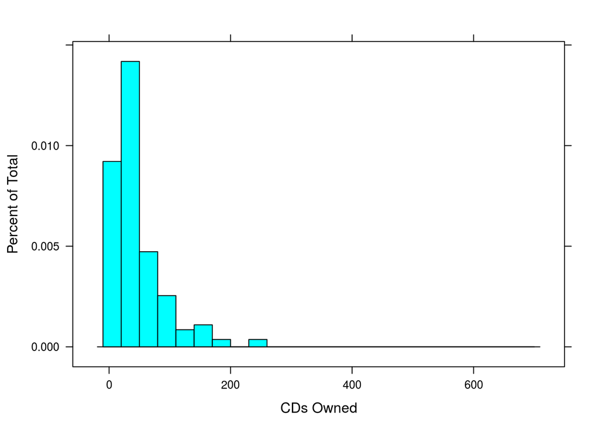

```r
require(lattice)
noOutlier = droplevels(subset(ss, cds<600))
histogram(~cds, data=noOutlier, breaks=c(-10, 20, 50, 80, 110, 140, 170, 200, 230, 260, 700), xlab="CDs Owned", ylab="Percent of Total")
```

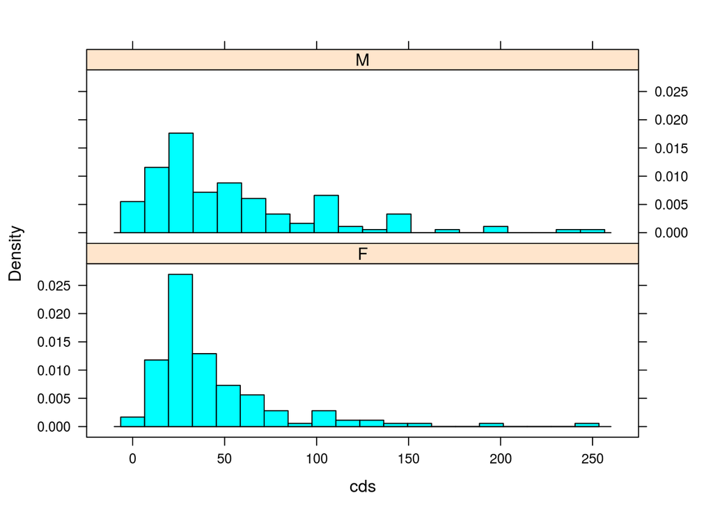

```r
histogram(~cds | gender, data=noOutlier, n=20, layout=c(1,2))
```

**Exercise 12** There are many similarities in the number of CDs owned accross the different regions. Nevertheless, CDs in the rural regions have a tighter distribution with a maximum of around 100 and a peak at around 25. The Urban and Suburban regions also have peaks below 50, but there are multiple subjects who own more than 100 CDs. Therefore, there are differences in CD ownership between Rural and the other regions, but the similarities show that most people own less than 50 CDs with a skew to the right accross all regions.

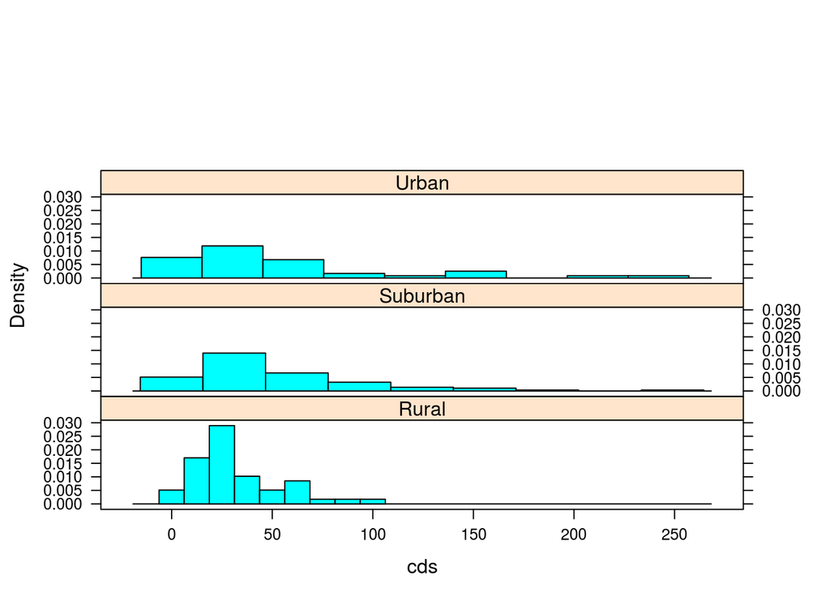

```r
cleanRegion = droplevels(subset(noOutlier, region!=""))
histogram(~cds | region, data=cleanRegion, layout=c(1,4))
```

**Exercise 13** There does not appear to be an association between pulse and gpa. If there were an association, we would expect that there would be a linear pattern in the data showing that as gpa increases or decreases the pulse consistently increases or decreases.

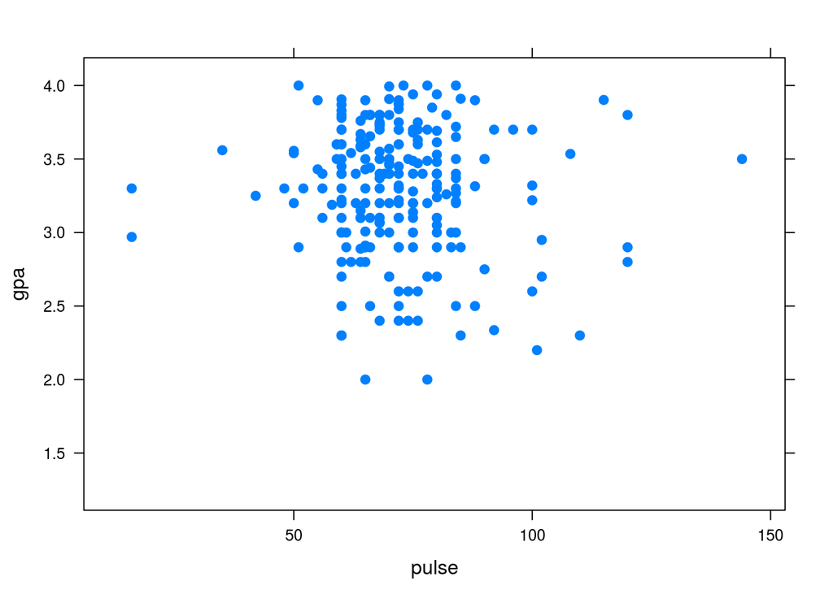

```r
xyplot(gpa ~ pulse, data=ss, pch=19, cex=.9)
```